# Processing of SP3 single-protein reproducibility data

### Description

- MGF files were generated using RawQuant.
- The data were searched using SearchCLI and PeptideShakerCLI.
- Raw files were parsed for quantification data with RawQuant.

### Analysis

First call the libraries that are required.

```r
#library(Biostrings)
library(Rmisc)
library(dplyr)
library(ggplot2)
library(RColorBrewer)
library(cowplot)
#library(reshape)
library(data.table)
#library(stringr)
#library(Peptides)
```

First thing we want to do is compile the identifications data into a usable object for plotting. This involves taking the output from PeptideShaker and combining it with the RawQuant data. This is carried out using the code below.

```r
###locate the input files for identifications and quantification
id_files = list.files('/projects/ptx_analysis/chughes/projects-current/sp3-follow-up/reproducibility-testing/reports-output', pattern='.*Default_PSM_Report.txt',full.names=TRUE) #psm files
quant_files = list.files('/projects/ptx_analysis/chughes/projects-current/sp3-follow-up/reproducibility-testing/quant-output', pattern='.*MS2ParseData.txt',full.names=TRUE) #ms2 files
###read in the identification data into a single data frame object, keeping only hits against bsa
id_parsed = data.frame() #identification data storage object
#iterate over the identification files
for (i in 1:length(id_files)){
  psm_in = read.table(id_files[i],header=TRUE,sep='\t') #input file
  psm_f1 = psm_in %>%
    dplyr::select(Protein.s., Sequence, Spectrum.File, Spectrum.Title, m.z, Identification.Charge) %>% #select columns
    dplyr::mutate(Spectrum.Title, scan_num = sub(".*?spectrum (.*?)", "\\1", Spectrum.Title)) %>% #parse out the scan number
    dplyr::mutate(Identification.Charge, id_charge = gsub("[^0-9]", "", Identification.Charge)) %>% #parse out the charge
    dplyr::mutate(Spectrum.Title, fraction = sub(".*?reproducibility_(.*?)_MGF\\.mgf", "\\1", Spectrum.File)) %>% #parse the fraction
    dplyr::mutate(Spectrum.Title, replicate = sub(".*?bsa_(.*?)_MGF\\.mgf", "\\1", Spectrum.File)) %>% #parse the replicate
    dplyr::select(Protein.s., Sequence, scan_num, m.z, id_charge, fraction, replicate) %>% #select new columns
    dplyr::mutate(Protein.s., first_accession = sapply(strsplit(as.character(Protein.s.),"\\,"), `[`, 1)) #parse the accession
  #adjust the column names
  colnames(psm_f1) = c('accession_groups','sequence','ScanNumber','id_precursor_mz','id_charge','fraction','replicate','accession')
  psm_f2 = dplyr::filter(psm_f1, grepl('CONT_ALBU_BOVIN', accession)) #keep only the bsa hits
  id_parsed = rbind(id_parsed,psm_f2) #group the data with the previously processed set
}
###now we can process the rawquant data for the intensity values
quant_parsed = data.frame()
#iterate over the rawquant files
for (i in 1:length(quant_files)){
  quant_in = read.table(quant_files[i],header=TRUE,sep='\t') #input file
  quant_in$fraction = sub(".*?reproducibility_(.*?)_MS2ParseData\\.txt", "\\1", quant_files[i]) #parse out the fraction
  quant_in$replicate = sub(".*?bsa_(.*?)_MS2ParseData\\.txt", "\\1", quant_files[i]) #parse out the replicate
  quant_parsed = rbind(quant_parsed, quant_in) #combine with the previous data
}
###now we can combine the two data sets together using a simple merge
id_quant = merge(id_parsed, quant_parsed, by=c('ScanNumber', 'fraction', 'replicate'))
saveRDS(id_quant, '/projects/ptx_analysis/chughes/projects-current/sp3-follow-up/reproducibility-testing/Routput/ch_feb2018_SP3-reproducibility-testing_id-quant-all.rds') #save the data
#done
```

Now that I have the compiled data set, I want to plot how well the identified peptides track across the different replicates. I can do this using their intensities from rawquant.

```r
###first read in the data file I just prepared
psm_set = readRDS('/projects/ptx_analysis/chughes/projects-current/sp3-follow-up/reproducibility-testing/Routput/ch_feb2018_SP3-reproducibility-testing_id-quant-all.rds') #read processed data
###collapse redundant psm's in the data
psm_agg <- setDT(psm_set)[, lapply(.SD,mean,na.rm=TRUE),by=.(sequence,replicate),.SDcols=c('PrecursorMaxIntensity')] #collapse by sequence and replicate
setDF(psm_agg) # convert back to dataframe
dim(psm_agg) #4184 rows are remaining
```

```
[1] 4184    3
```

```r
###only interested in peptides that were identified in all 24 samples for this specific plot
peptide_set = names(which(table(psm_agg$sequence) == 24)) #extract the peptides found in all 24 fractions, this keeps 76 peptides
peptide_subset = psm_agg[psm_agg$sequence %in% peptide_set,] #filter the data matrix to only keep peptides found in all 24 fractions
dim(peptide_subset) #this should be 76 * 24 rows in length, and it is!
```

```
[1] 1824    3
```

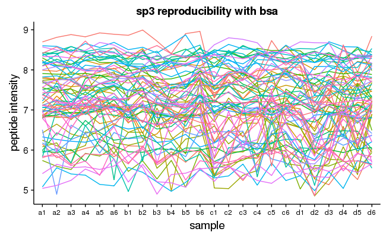

```r
###now plot the data
reproducibility_plot = ggplot(peptide_subset, aes(replicate, log10(PrecursorMaxIntensity), group = sequence)) +
    geom_line(aes(color = sequence)) +
    labs(x = "sample", y = 'peptide intensity', title = 'sp3 reproducibility with bsa') +
    theme(axis.text.x = element_text(size = 9)) +
    #scale_y_continuous(limits=c(0,1.5e9)) +
    theme(legend.position="none")
reproducibility_plot #call the plot
save_plot('/projects/ptx_analysis/chughes/projects-current/sp3-follow-up/reproducibility-testing/Routput/ch_feb2018_SP3-reproducibility-testing_peptide-lineplot.pdf',reproducibility_plot)
```

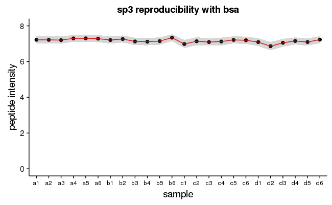

```r
###that plot is pretty hard to visualize. What about taking a per-sample reading and plotting the confidence intervals
peptide_CI = group.CI(log10(PrecursorMaxIntensity)~replicate,peptide_subset) #calculate CI values
colnames(peptide_CI) = c('replicate','upper','mean_intensity','lower') #rename the columns
###now replot the data
CI_plot = ggplot(peptide_CI, aes(x = replicate, y = mean_intensity, group = 1)) +
    geom_point(size = 2) +
    geom_line(color = 'red') +
    geom_ribbon(aes(ymin = lower, ymax = upper), linetype = 2, alpha = 0.2) +
    labs(x = "sample", y = 'peptide intensity', title = 'sp3 reproducibility with bsa') +
    theme(axis.text.x = element_text(size = 9)) +
    scale_y_continuous(limits=c(0,8)) +
    theme(legend.position="none")
CI_plot #call the plot
save_plot('/projects/ptx_analysis/chughes/projects-current/sp3-follow-up/reproducibility-testing/Routput/ch_feb2018_SP3-reproducibility-testing_peptide-logCIplot.pdf',CI_plot)
```

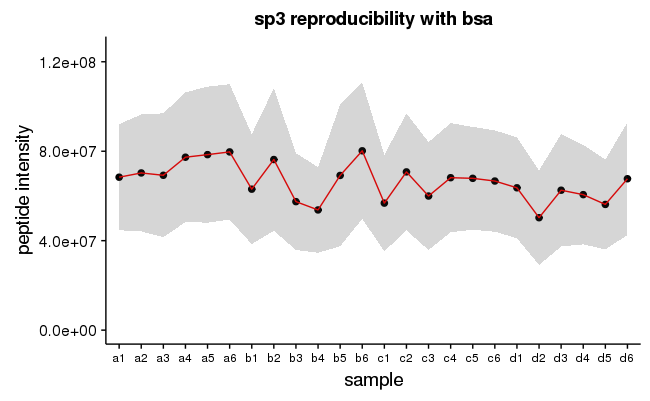

```r
###looks good...but what does it look like without log transforming?
peptide_CI = group.CI(PrecursorMaxIntensity~replicate,peptide_subset) #calculate CI values
colnames(peptide_CI) = c('replicate','upper','mean_intensity','lower') #rename the columns
###now replot the data
CI_plot_int = ggplot(peptide_CI, aes(x = replicate, y = mean_intensity, group = 1)) +
    geom_point(size = 2) +
    geom_line(color = 'red') +
    geom_ribbon(aes(ymin = lower, ymax = upper), linetype = 2, alpha = 0.2) +
    labs(x = "sample", y = 'peptide intensity', title = 'sp3 reproducibility with bsa') +
    theme(axis.text.x = element_text(size = 9)) +
    scale_y_continuous(limits=c(0,1.25e8)) +
    theme(legend.position="none")
CI_plot_int #call the plot
save_plot('/projects/ptx_analysis/chughes/projects-current/sp3-follow-up/reproducibility-testing/Routput/ch_feb2018_SP3-reproducibility-testing_peptide-CIplot.pdf',CI_plot_int)
```

```r
#so looks a bit more noisy, but to be expected. Still looks good to me.
#done.
```

Now that I have that data, I would also like to see how well the actual identification of peptides stacked up along the different runs. For this a simple barplot of the number of unique peptide assigned to bsa for each replicate will be enough I think.

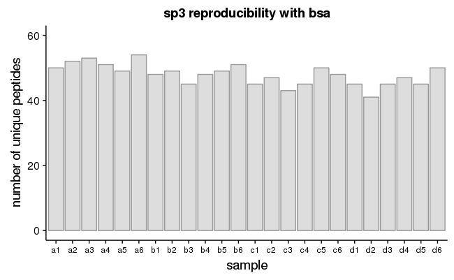

```r
###first read in the data file I prepared previously
psm_set = readRDS('/projects/ptx_analysis/chughes/projects-current/sp3-follow-up/reproducibility-testing/Routput/ch_feb2018_SP3-reproducibility-testing_id-quant-all.rds') #read processed data
###collapse redundant psm's in the data
psm_set$psms = 1 #add a psm counter
psm_agg <- setDT(psm_set)[, lapply(.SD,sum,na.rm=TRUE),by=.(sequence,replicate),.SDcols=c('psms')] #collapse by sequence and replicate
setDF(psm_agg) #convert back to data frame
psm_agg = subset(psm_agg, psms>=5) #filter by number of psms
###now plot the data
peptide_plot = ggplot(psm_agg, aes(x = replicate)) +
    geom_bar(color = 'grey60', alpha = 0.2) +
    labs(x = "sample", y = 'number of unique peptides', title = 'sp3 reproducibility with bsa') +
    theme(axis.text.x = element_text(size = 9)) +
    scale_y_continuous(limits=c(0,60)) +
    theme(legend.position="none")
peptide_plot #call the plot
save_plot('/projects/ptx_analysis/chughes/projects-current/sp3-follow-up/reproducibility-testing/Routput/ch_feb2018_SP3-reproducibility-testing_peptide-id-barplot.pdf',peptide_plot)
```

```r
#these numbers are high, but is primarily driven by overlapping fragments of the same peptides being counted, as well as non-tryptic peptides that have been identified.
#most of them are single peptide hits...we could filter to use anything with >5 psms as the 'core' peptide for that sequence
#done
```

Done.